# О промышленном производстве в I квартале 2026 года

[figure not shown]

О ПРОМЫШЛЕННОМ ПРОИЗВОДСТВЕ  
В I КВАРТАЛЕ 2026 ГОДА1,2,3

Индекс промышленного производства* составил:

– в I квартале 2026 г. по сравнению с I кварталом 2025 г. – 100,3%;

– в марте 2026 г. по сравнению с мартом 2025 г. – 102,3%, по сравнению с февралем 2026 г. – 112,4%.

Индекс промышленного производства  
в % к среднемесячному значению 2023 года

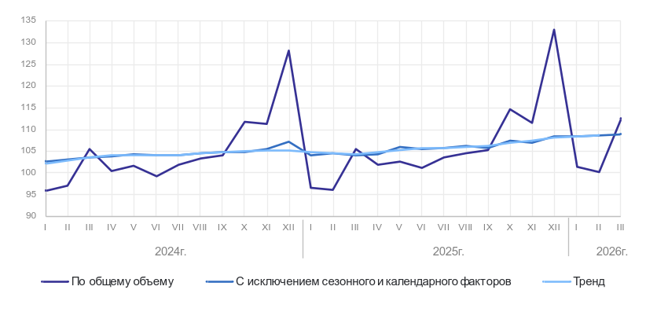

________________________

* Индекс промышленного производства исчисляется по видам деятельности «Добыча полезных ископаемых», «Обрабатывающие производства», «Обеспечение электрической энергией, газом и паром; кондиционирование воздуха», «Водоснабжение; водоотведение, организация сбора и утилизации отходов, деятельность по ликвидации загрязнений» в соответствии с Официальной статистической методологией исчисления индекса промышленного производства (приказ Росстата от 16.01.2020 № 7) на основе данных о динамике производства важнейших товаров-представителей в физическом измерении, оцененных за 2025 год в ценах базисного 2018 года, с января 2026 года – в ценах базисного 2023 года. В качестве весов за 2025 год используется структура валовой добавленной стоимости по видам экономической деятельности 2018 базисного года, с января 2026 года – 2023 базисного года.

Индексы промышленного производства

В % к

соответст-  
вующему  
периоду  
предыдущего  
года

предыдущему  
периоду

среднемесячному значению  
2023 г.

фактически

с исключением  
сезонного  
и календарного  
факторов*

фактически

с исключением  
сезонного  
и календарного  
факторов*

2025 г.

## Январь

101,0

75,4

97,1

96,7

104,1

## Февраль

99,1

99,4

100,6

96,1

104,7

## Март

100,2

109,9

99,4

105,6

104,1

## I квартал

100,1

84,9

## Апрель

101,3

96,4

100,3

101,8

104,3

## Май

101,2

100,9

101,5

102,7

105,9

## Июнь

102,1

98,6

99,7

101,3

105,6

## II квартал

101,5

102,5

## I полугодие

100,8

## Июль

101,5

102,2

100,2

103,5

105,8

## Август

101,0

101,0

100,4

104,5

106,3

## Сентябрь

101,1

100,7

99,6

105,3

105,8

## III квартал

101,2

102,4

## Январь-сентябрь

100,9

## Октябрь

102,5

108,9

101,5

114,6

107,3

## Ноябрь

100,4

97,4

99,6

111,7

106,9

## Декабрь

103,7

119,0

101,4

132,9

108,4

## IV квартал

102,3

114,7

## Год

101,3

2026 г.

## Январь

99,2

76,3

100,0

101,4

108,4

## Февраль

99,1

98,8

100,2

100,2

108,7

## Март

102,3

112,4

100,2

112,6

108,9

## I квартал

100,3

86,2

* Оценки данных с исключением сезонного и календарного факторов осуществлены с использованием программы "JDEMETRA+". При поступлении новых данных статистических наблюдений динамика может быть уточнена.

Динамика производства по видам экономической деятельности  
в процентах

Добыча  
полезных  
ископаемых

Обрабатывающие  
производства

Обеспечение  
электрической  
энергией, газом  
и паром;  
кондиционирование  
воздуха

Водоснабжение;  
водоотведение,  
организация сбора  
и утилизации  
отходов,  
деятельность  
по ликвидации  
загрязнений

к соот-  
ветст-  
вующему  
периоду  
преды-  
дущего  
года

к преды-  
дущему  
периоду

к соот-  
ветст-  
вующему  
периоду  
преды-  
дущего  
года

к преды-  
дущему  
периоду

к соот-  
ветст-  
вующему  
периоду  
преды-  
дущего  
года

к преды-  
дущему  
периоду

к соот-  
ветст-  
вующему  
периоду  
преды-  
дущего  
года

к преды-  
дущему  
периоду

2025 г.

## Январь

97,5

89,9

105,4

65,4

92,6

97,2

100,1

74,0

## Февраль

94,5

91,8

102,6

105,4

96,6

94,6

95,3

101,4

## Март

95,4

109,6

103,7

112,6

97,8

96,9

95,3

103,9

## I квартал

95,8

92,2

103,9

78,6

95,5

104,4

96,8

84,0

## Апрель

98,5

97,1

103,1

97,5

101,9

84,9

93,9

102,8

## Май

98,3

102,5

103,3

101,8

99,1

86,6

95,2

102,5

## Июнь

98,9

95,6

104,5

101,5

98,8

88,2

96,0

101,9

## II квартал

98,6

100,5

103,6

109,0

100,1

71,5

95,0

108,3

## I полугодие

97,2

103,7

97,4

95,9

## Июль

100,0

103,7

102,8

101,3

99,5

105,0

93,8

95,4

## Август

97,7

100,2

103,3

101,6

99,8

99,4

93,9

98,1

## Сентябрь

100,4

100,5

101,6

100,5

101,1

102,8

98,7

104,7

## III квартал

99,4

101,8

102,5

104,1

100,1

92,0

95,4

97,7

## Январь-сентябрь

97,9

103,3

98,1

95,7

## Октябрь

101,4

105,2

103,5

109,3

101,1

127,6

96,1

100,7

## Ноябрь

100,4

97,3

101,0

96,3

96,6

107,7

96,8

98,7

## Декабрь

97,2

105,6

107,8

126,6

99,3

116,4

93,8

115,0

## IV квартал

99,6

105,6

104,3

117,0

99,0

144,0

95,5

107,4

## Год

98,4

103,6

98,4

95,7

2026 г.

## Январь

100,5

95,4

97,0

62,5

107,5

105,7

93,0

73,4

## Февраль

100,9

91,6

97,2

106,0

103,6

91,0

97,9

106,8

## Март

101,0

110,2

103,0

117,5

100,1

93,7

97,6

104,4

## I квартал

100,8

94,4

99,3

78,3

103,8

109,6

96,2

84,2

Индексы производства по основным видам добывающих  
и обрабатывающих производств*

[output not shown]

Выпуск важнейших видов продукции

[output not shown]

[output cut: 117 more lines]

___________________

1 Без учета статистической информации по Донецкой Народной Республике, Луганской Народной Республике, Запорожской и Херсонской областям.

2 Информация о добыче нефти не публикуется на основании распоряжения Правительства Российской Федерации от 26.04.2023 № 1074-р (ред. от 31.03.2026).

3 Информация о производстве нефтепродуктов не публикуется на основании решения Правительства Российской Федерации, принятого в соответствии с частью 10 статьи 5 Федерального закона от 29.11.2007 № 282-ФЗ «Об официальном статистическом учете и системе государственной статистики в Российской Федерации».